# Lecture 11 — Camera Geometry

Lecture 11

Kaveh Fathian

Computer Science Department, Colorado School of Mines

## Learning Objectives

By the end of this lecture, you should be able to:

- Explain the pinhole camera model, its connection to a lens camera, and the effects of focal length and object distance.
- Use homogeneous coordinates to represent and compose transformations, and distinguish rigid, similarity, affine, and projective transformations.
- Explain how extrinsic and intrinsic parameters map a world point to an image pixel.
- Project 3D points using the camera matrix and OpenCV.

## A Brief History: The Camera Obscura

- Light through a small hole in a dark room forms an **inverted image** of the scene on the opposite wall.
- This pinhole effect was described by Mozi (c. 470–391 BC); Aristotle (384–322 BC) used it to watch solar eclipses.

[figure not shown]

Frisius’s woodcut is the oldest known published drawing of a camera obscura.

## A Brief History: Recording the Image

[figure not shown]

- **Niépce:** exposure of about 8 hours; held at the Harry Ransom Center, UT Austin.
- **Daguerre:** moving traffic left no trace; a man having his boots polished stood still long enough to appear.
- **Sasson:** $100\times100$ pixels (0.01 megapixels), black and white, stored on cassette tape; 23 seconds per image, about 8 pounds.

## Bare Sensor vs. Pinhole

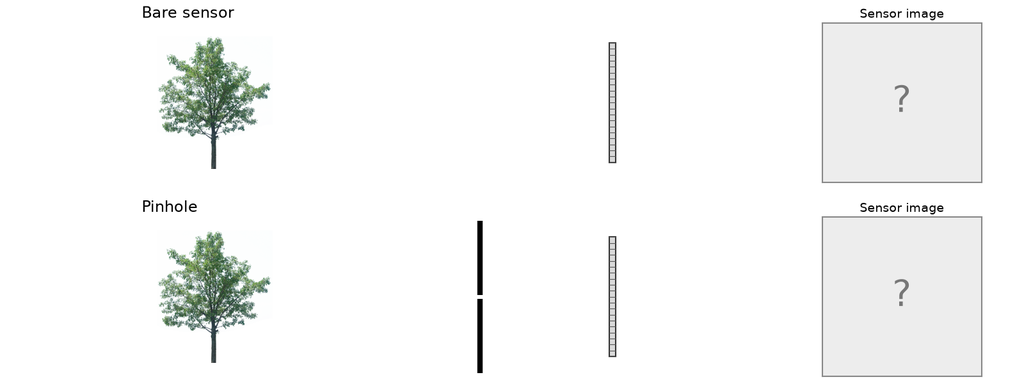

- **Bare sensor:** every scene point reaches every pixel, so every pixel records nearly the same average color.
- **Pinhole:** the barrier blocks all but one ray from each point, so each pixel sees one scene point: an **inverted** image.

## Pinhole Camera Terms

[figure not shown]

- The **pinhole** is the **camera center** (center of projection): every ray that forms the image passes through it.
- The sensor lies in the **image plane**, a distance $f$ (the **focal length**) behind the pinhole.

## Focal Length

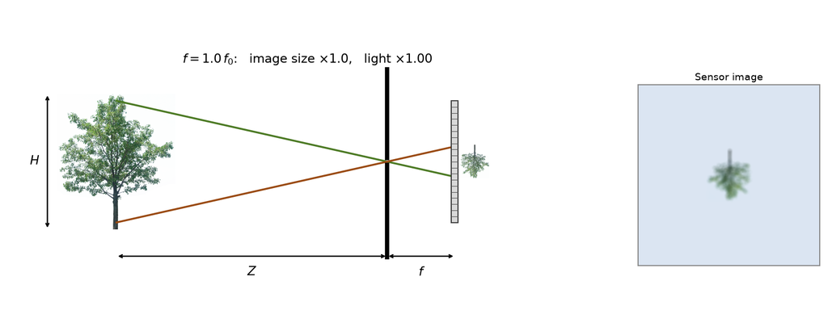

- Image size is $f\,H/Z$: doubling $f$ doubles the image and narrows the field of view.
- With the same pinhole, the light reaching each pixel is proportional to $1/f^2$: doubling $f$ gives ¼ of the light.

## Pinhole Size: Sharpness vs. Light

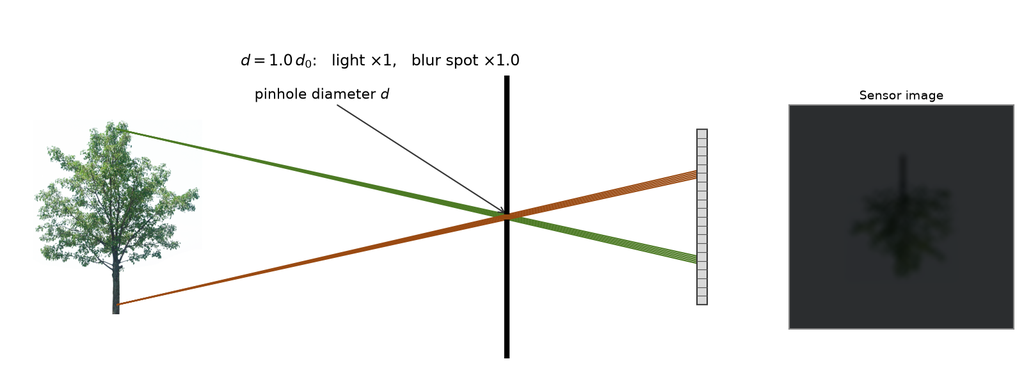

- Light collected grows with the pinhole’s area ($\propto d^2$), but each scene point spreads over a spot of size $\propto d$.
- A very small pinhole is sharp but dark; below a certain size, **diffraction** blurs the image again, so the pinhole cannot be made arbitrarily small.

## The Lens Camera

[figure not shown]

- A lens collects a **bundle of rays** from each scene point and focuses them back to one image point: far **more light** than a pinhole, **without the blur**.
- The **central ray** (thick) passes through the lens center undeflected, just as through a pinhole. When the lens is in focus, the pinhole model gives where each point lands.

## Focal Length of a Lens

- In a lens camera, the **focal length** $f$ is the distance at which **parallel rays** intersect (the focal point F).
- The image of an object at distance $D$ forms at the **focus distance** $D'$: $\;\frac{1}{D} + \frac{1}{D'} = \frac{1}{f}$.
- The pinhole model describes a lens camera if:
  - We use only central rays
  - The lens is in focus
  - The pinhole’s focal length equals the lens’s focus distance $D'$; for a distant object, $D' = f$.
- In this course, **focal length** $f$ means the **aperture–sensor distance**, as in the pinhole camera.

[figure not shown]

## The Virtual Image Plane

- Placing a virtual image plane a distance $f$ **in front of** the camera center gives the same image, the same size, but **upright**.
- The virtual plane is mathematically equivalent and easier to work with, so from now on we will use it instead.

[figure not shown]

## The Camera Coordinate Frame

- Origin is at the **camera center**.
- Convention: $x$ right, $y$ down, $z$ forward.
- The $z$-axis is the **principal (optical) axis**.
- The image plane is $z = f$.
- The principal axis meets the image plane at the **principal point**.
- A 3D point ${}^{c}\mathbf{X} = (X, Y, Z)$ in camera coordinates projects to the point $\mathbf{x} = (x, y)$ where the ray to the camera center crosses the image plane.

[figure not shown]

## Perspective Projection

- Side view ($y$–$z$ plane): the two shaded triangles are **similar**, so
  $$\frac{y}{f} = \frac{Y}{Z}, \qquad \text{and likewise} \qquad \frac{x}{f} = \frac{X}{Z}.$$
- **Perspective projection:**
  $$(X,\ Y,\ Z) \;\mapsto\; \left(f\,\frac{X}{Z},\; f\,\frac{Y}{Z}\right)$$
- The division by $Z$ makes the projection **nonlinear** in $(X, Y, Z)$.
- Homogeneous coordinates (defined later) will make it a matrix product.

[figure not shown]

## Consequences of Perspective Projection

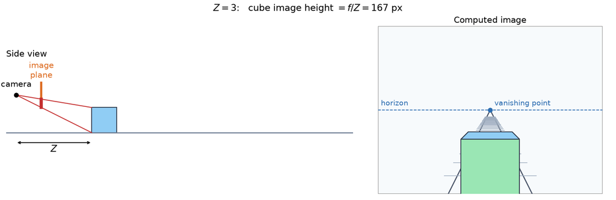

- **Size $\propto 1/Z$:** doubling the distance halves the image of the cube.
- **Depth is lost:** every point on a ray through the camera center projects to the same image point.
- **Vanishing points:** parallel 3D lines (the rails) meet at one image point, on the **horizon**.

## Consequences of Perspective Projection

[figure not shown]

StruckDuck, [*Impossible Gravity Slide Illusion*](https://www.youtube.com/watch?v=pt5xnzvImdg)

[video not shown]

## Fundamental Equations of Computer Vision

[output not shown]

## Homogeneous Coordinates

- Introduced by **August Ferdinand Möbius** (1827), as an alternative to Cartesian coordinates for projective geometry.
- Add **one extra coordinate**: a 2D point gets 3 numbers, a 3D point gets 4.
- Why we use them in computer vision:
  - **Translation** becomes a matrix product
  - **Perspective projection** becomes a matrix product
  - A chain of transformations becomes a **single matrix**

[figure not shown]

## Converting To and From Homogeneous Coordinates

|  | **To homogeneous:** append a 1 | **From homogeneous:** divide by the last coordinate |
| --- | --- | --- |
| **2D** (image) | $(x, y) \;\Rightarrow\; \begin{bmatrix} x \\ y \\ 1 \end{bmatrix}$ | $\begin{bmatrix} x \\ y \\ w \end{bmatrix} \;\Rightarrow\; \left(\dfrac{x}{w},\ \dfrac{y}{w}\right)$ |
| **3D** (scene) | $(x, y, z) \;\Rightarrow\; \begin{bmatrix} x \\ y \\ z \\ 1 \end{bmatrix}$ | $\begin{bmatrix} x \\ y \\ z \\ w \end{bmatrix} \;\Rightarrow\; \left(\dfrac{x}{w},\ \dfrac{y}{w},\ \dfrac{z}{w}\right)$ |

- Example: $(2, 3) \Rightarrow (2, 3, 1) \sim (4, 6, 2) \Rightarrow (2, 3)$: **scaling a homogeneous vector does not change the point** it represents.
- $w = 0$ has no Cartesian equivalent: it is a **point at infinity** (a direction), such as the vanishing point where parallel lines meet.

## A Point Is a Ray

- All multiples of a homogeneous vector are the **same point**:
  $$k\begin{bmatrix} x \\ y \\ w \end{bmatrix} \sim \begin{bmatrix} x \\ y \\ w \end{bmatrix}, \quad k \neq 0$$
- So a 2D point is a **ray through the origin**; its Cartesian coordinates are where the ray crosses the plane $w = 1$.
- This is the pinhole camera: every 3D point on a ray through the camera center lands on the same image point (scale ambiguity).

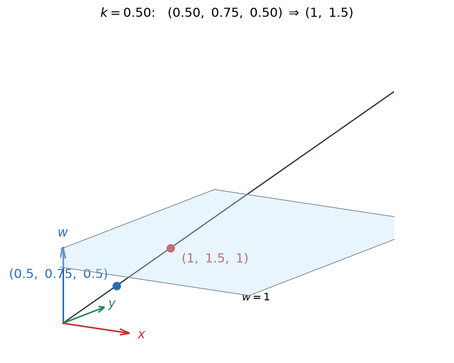

## Parametric (Global) Transformations

- A **transformation** $T$ maps every point $\mathbf{p} = (x, y)$ to a new point $\mathbf{p}' = T(\mathbf{p})$.
- **Parametric:** $T$ is described by a few numbers (its parameters).
- **Global:** the same $T$ applies to every point of the image.
- If $T$ is **linear**, it is a **matrix**: $\mathbf{p}' = \mathbf{M}\,\mathbf{p}$,

$$\begin{bmatrix} p'_x \\ p'_y \end{bmatrix} =
\underbrace{\begin{bmatrix} m_{11} & m_{12} \\ m_{21} & m_{22} \end{bmatrix}}_{\mathbf{M}}
\begin{bmatrix} p_x \\ p_y \end{bmatrix} .$$

[figure not shown]

## Translation as a Matrix Product

- In Cartesian coordinates, translation is **not** a matrix product:
  $$\begin{bmatrix} x' \\ y' \end{bmatrix} = \begin{bmatrix} x \\ y \end{bmatrix} + \begin{bmatrix} t_x \\ t_y \end{bmatrix}$$
- In homogeneous coordinates, it is:
  $$\begin{bmatrix} x' \\ y' \\ 1 \end{bmatrix} = \begin{bmatrix} 1 & 0 & t_x \\ 0 & 1 & t_y \\ 0 & 0 & 1 \end{bmatrix} \begin{bmatrix} x \\ y \\ 1 \end{bmatrix}$$
- Rotation, scaling, translation, and projection all become matrices, so a sequence of them is one matrix product.

[figure not shown]

## 2D Transformation Matrices

[figure not shown]

|  | Translation | Uniform scale | Non-uniform scale | Shear | Rotation |
| --- | --- | --- | --- | --- | --- |
| **Cartesian** | none: $\mathbf{p}' = \mathbf{p} + \mathbf{t}$ | $\begin{bmatrix} s & 0 \\ 0 & s \end{bmatrix}$ | $\begin{bmatrix} s_x & 0 \\ 0 & s_y \end{bmatrix}$ | $\begin{bmatrix} 1 & a_x \\ a_y & 1 \end{bmatrix}$ | $\begin{bmatrix} \cos\theta & -\sin\theta \\ \sin\theta & \cos\theta \end{bmatrix}$ |
| **Homogeneous** | $\begin{bmatrix} 1 & 0 & t_x \\ 0 & 1 & t_y \\ 0 & 0 & 1 \end{bmatrix}$ | $\begin{bmatrix} s & 0 & 0 \\ 0 & s & 0 \\ 0 & 0 & 1 \end{bmatrix}$ | $\begin{bmatrix} s_x & 0 & 0 \\ 0 & s_y & 0 \\ 0 & 0 & 1 \end{bmatrix}$ | $\begin{bmatrix} 1 & a_x & 0 \\ a_y & 1 & 0 \\ 0 & 0 & 1 \end{bmatrix}$ | $\begin{bmatrix} \cos\theta & -\sin\theta & 0 \\ \sin\theta & \cos\theta & 0 \\ 0 & 0 & 1 \end{bmatrix}$ |

- Scale, shear, and rotation are **linear**: they keep the origin fixed. Translation is not, so it has no $2\times2$ matrix.
- In homogeneous coordinates, **every** one of them is a $3\times3$ matrix.

## Composing Transformations

$$\mathbf{R} = \begin{bmatrix} \cos 45^\circ & -\sin 45^\circ & 0 \\ \sin 45^\circ & \cos 45^\circ & 0 \\ 0 & 0 & 1 \end{bmatrix}\qquad\qquad \mathbf{T} = \begin{bmatrix} 1 & 0 & 2.2 \\ 0 & 1 & 0 \\ 0 & 0 & 1 \end{bmatrix}$$

[figure not shown]

$$\mathbf{T}\,\mathbf{R} = \begin{bmatrix} 0.71 & -0.71 & 2.2 \\ 0.71 & 0.71 & 0 \\ 0 & 0 & 1 \end{bmatrix}$$

[figure not shown]

$$\mathbf{R}\,\mathbf{T} = \begin{bmatrix} 0.71 & -0.71 & 1.56 \\ 0.71 & 0.71 & 1.56 \\ 0 & 0 & 1 \end{bmatrix}$$

- A chain of transformations is **one matrix**, and the rightmost is applied first. **Order matters:** $\mathbf{T}\,\mathbf{R} \neq \mathbf{R}\,\mathbf{T}$.

## The 2D Transformation Hierarchy

[figure not shown]

| Transformation | Matrix | DOF | Preserves (and everything below) |
| --- | --- | --- | --- |
| Translation | $\begin{bmatrix} \mathbf{I} & \mathbf{t} \\ \mathbf{0}^{T} & 1 \end{bmatrix}$ | 2 | orientation |
| Rigid (Euclidean) | $\begin{bmatrix} \mathbf{R} & \mathbf{t} \\ \mathbf{0}^{T} & 1 \end{bmatrix}$ | 3 | lengths |
| Similarity | $\begin{bmatrix} s\mathbf{R} & \mathbf{t} \\ \mathbf{0}^{T} & 1 \end{bmatrix}$ | 4 | angles |
| Affine | $\begin{bmatrix} \mathbf{A} & \mathbf{t} \\ \mathbf{0}^{T} & 1 \end{bmatrix}$ | 6 | parallelism |
| Projective | $\mathbf{H}$ (any invertible $3\times3$) | 8 | straight lines |

## Affine Transformations

- Any combination of linear transformations and translation:
  $$\begin{bmatrix} x' \\ y' \\ 1 \end{bmatrix} = \begin{bmatrix} a & b & c \\ d & e & f \\ 0 & 0 & 1 \end{bmatrix} \begin{bmatrix} x \\ y \\ 1 \end{bmatrix}$$
- 6 DOF; the last row is always $[\,0\ \ 0\ \ 1\,]$.
- Properties:
  - Lines map to lines
  - **Parallel lines stay parallel**
  - **Ratios** along a line are kept (a midpoint stays a midpoint)
  - Closed under composition

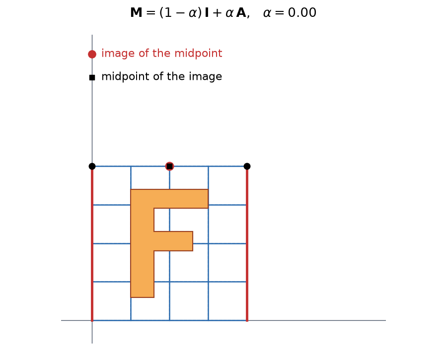

## Projective Transformations (Homographies)

- A general $3\times3$ matrix in homogeneous coordinates:
  $$\begin{bmatrix} x' \\ y' \\ w' \end{bmatrix} = \begin{bmatrix} h_{11} & h_{12} & h_{13} \\ h_{21} & h_{22} & h_{23} \\ h_{31} & h_{32} & h_{33} \end{bmatrix} \begin{bmatrix} x \\ y \\ 1 \end{bmatrix}$$
- Divide by $w'$ to get the point: a **projective warp**.
- 8 DOF: $\mathbf{H}$ is defined only up to scale.
- Properties:
  - Lines map to lines
  - Parallel lines **do not stay parallel**
  - Ratios are **not** kept
  - Closed under composition

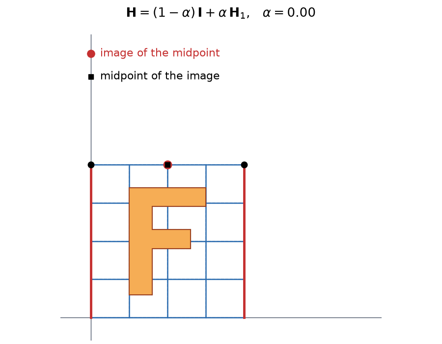

## Cameras Are Projective Transformation Machines

[figure not shown]

- A camera maps a **plane** in the world to the image by a homography, so two views of the same plane are related by a homography $\mathbf{H}$.
- This works only because the scene is **flat**: for a 3D scene, points at different depths shift by different amounts between views, so no single $\mathbf{H}$ relates them.

## 3D Rotation and Translation

[figure not shown]

|  | Translation | Rotation | Rotation + translation (rigid) |
| --- | --- | --- | --- |
| **Cartesian** | none: $\mathbf{X}' = \mathbf{X} + \mathbf{t}$ | $\mathbf{X}' = \mathbf{R}\,\mathbf{X}$ | $\mathbf{X}' = \mathbf{R}\,\mathbf{X} + \mathbf{t}$ |
| **Homogeneous** ($4\times4$) | $\begin{bmatrix} \mathbf{I} & \mathbf{t} \\ \mathbf{0}^{T} & 1 \end{bmatrix}$ | $\begin{bmatrix} \mathbf{R} & \mathbf{0} \\ \mathbf{0}^{T} & 1 \end{bmatrix}$ | $\begin{bmatrix} \mathbf{R} & \mathbf{t} \\ \mathbf{0}^{T} & 1 \end{bmatrix}$ |

- $\mathbf{R}$ is a $3\times3$ rotation; e.g., about $z$ it is the 2D rotation with a 1 added: $\;\mathbf{R}_z(\theta) = \begin{bmatrix} \cos\theta & -\sin\theta & 0 \\ \sin\theta & \cos\theta & 0 \\ 0 & 0 & 1 \end{bmatrix}$
- Every 3D rotation has $\mathbf{R}^{T}\mathbf{R} = \mathbf{I}$, $\det\mathbf{R} = 1$, and **3 DOF** (e.g., $\mathbf{R} = \mathbf{R}_z\mathbf{R}_y\mathbf{R}_x$). A rigid transformation has **6 DOF** ($3 + 3$).

## Changing Coordinate Frames

- The same $[\,\mathbf{R} \mid \mathbf{t}\,]$ can **move a point** within one frame, or **change frames** (i.e., give the coordinates of one fixed point in another frame):
  $${}^{b}\mathbf{X} = {}^{b}\mathbf{R}_{a}\;{}^{a}\mathbf{X} + {}^{b}\mathbf{t}_{a}
  \qquad
  {}^{b}\mathbf{T}_{a} = \begin{bmatrix} {}^{b}\mathbf{R}_{a} & {}^{b}\mathbf{t}_{a} \\ \mathbf{0}^{T} & 1 \end{bmatrix}$$
  - Columns of ${}^{b}\mathbf{R}_{a}$: the axes of $a$ in frame $b$.
  - ${}^{b}\mathbf{t}_{a}$: the origin of $a$ in frame $b$.
- **Inverse:**
  $${}^{a}\mathbf{T}_{b} = \left({}^{b}\mathbf{T}_{a}\right)^{-1} = \begin{bmatrix} {}^{b}\mathbf{R}_{a}^{T} & -{}^{b}\mathbf{R}_{a}^{T}\,{}^{b}\mathbf{t}_{a} \\ \mathbf{0}^{T} & 1 \end{bmatrix}$$
- **Composition:** ${}^{c}\mathbf{T}_{a} = {}^{c}\mathbf{T}_{b}\;{}^{b}\mathbf{T}_{a}$ (matching inner frames cancel).

[figure not shown]

## Camera Model: From a World Point to a Pixel

[figure not shown]

| 1. Extrinsics | 2. Perspective projection | 3. Intrinsics |
| --- | --- | --- |
| world frame $\to$ camera frame | camera frame $\to$ image plane | image plane $\to$ pixels |

Each step is a matrix in homogeneous coordinates, so **the whole camera model is one matrix**.

## Step 1 — World to Camera (Extrinsics)

- Points are given in a **world** frame $w$; projection needs them in the **camera** frame $c$:
  $${}^{c}\mathbf{X} = {}^{c}\mathbf{R}_{w}\;{}^{w}\mathbf{X} + {}^{c}\mathbf{t}_{w}
  \qquad
  {}^{c}\mathbf{T}_{w} = \begin{bmatrix} {}^{c}\mathbf{R}_{w} & {}^{c}\mathbf{t}_{w} \\ \mathbf{0}^{T} & 1 \end{bmatrix}$$
- The **extrinsic matrix** is the top three rows of ${}^{c}\mathbf{T}_{w}$: $\big[\,{}^{c}\mathbf{R}_{w} \mid {}^{c}\mathbf{t}_{w}\,\big]$ ($3\times4$).
- The camera center ${}^{w}\mathbf{C}$ maps to ${}^{c}\mathbf{X} = \mathbf{0}$, so ${}^{c}\mathbf{t}_{w} = -\,{}^{c}\mathbf{R}_{w}\,{}^{w}\mathbf{C}$.
- **6 DOF:** camera position is 3 and its orientation is 3.

[figure not shown]

- Example: ${}^{w}\mathbf{C} = ({3.6},\ {-2.4},\ {2.2})$, and the red corner ${}^{w}\mathbf{X} = ({1.4},\ {1.4},\ {1.0})$ becomes ${}^{c}\mathbf{X} = ({0.70},\ {-0.49},\ {4.47})$.

## Step 2 — Camera to Image Plane (Projection)

- With ${}^{c}\mathbf{X} = (X_c, Y_c, Z_c)$, perspective projection $x = f X_c / Z_c$, $\ y = f Y_c / Z_c$ is a matrix product in homogeneous coordinates:
  $$Z_c \begin{bmatrix} x \\ y \\ 1 \end{bmatrix}
  = \begin{bmatrix} f X_c \\ f Y_c \\ Z_c \end{bmatrix}
  = \begin{bmatrix} f & 0 & 0 & 0 \\ 0 & f & 0 & 0 \\ 0 & 0 & 1 & 0 \end{bmatrix}
  \begin{bmatrix} X_c \\ Y_c \\ Z_c \\ 1 \end{bmatrix}$$
- The homogeneous scale is the **depth** $\lambda = Z_c$: we divide by it only at the end.
- All points on a ray through the camera center give the **same** $(x, y)$: depth is lost.

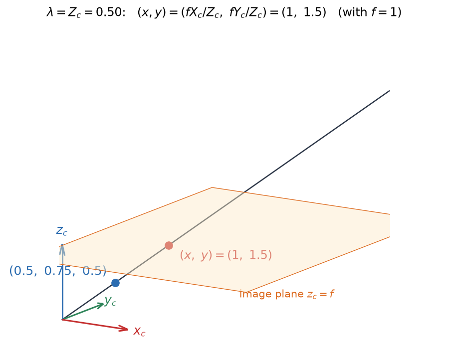

- Example ($f = 2.5$ mm): ${}^{c}\mathbf{X} = ({0.70},\ {-0.49},\ {4.47})$ m $\Rightarrow$ $(x, y) = ({0.393},\ {-0.274})$ mm, with $\lambda = 4.47$.

## Step 3 — Image Plane to Pixels (Intrinsics)

- $(x, y)$ are in mm, with the origin at the **principal point**.
- Pixel coordinates $(u, v)$ start at the **top-left** pixel.
- With pixel size $\rho_x \times \rho_y$ (mm) and the principal point at pixel $(c_x, c_y)$:
  $$u = \frac{x}{\rho_x} + c_x, \qquad v = \frac{y}{\rho_y} + c_y$$
- As a matrix in homogeneous coordinates:
  $$\begin{bmatrix} u \\ v \\ 1 \end{bmatrix} = \begin{bmatrix} \tfrac{1}{\rho_x} & 0 & c_x \\ 0 & \tfrac{1}{\rho_y} & c_y \\ 0 & 0 & 1 \end{bmatrix} \begin{bmatrix} x \\ y \\ 1 \end{bmatrix}$$

[figure not shown]

## The Intrinsic Matrix $\mathbf{K}$

- Steps 2 and 3 combine into one matrix: projection with $f$, then conversion to pixels:

$$\underbrace{\begin{bmatrix} \tfrac{1}{\rho_x} & 0 & c_x \\ 0 & \tfrac{1}{\rho_y} & c_y \\ 0 & 0 & 1 \end{bmatrix}}_{\text{to pixels}}
\underbrace{\begin{bmatrix} f & 0 & 0 \\ 0 & f & 0 \\ 0 & 0 & 1 \end{bmatrix}}_{\text{focal length}}
= \begin{bmatrix} f_x & 0 & c_x \\ 0 & f_y & c_y \\ 0 & 0 & 1 \end{bmatrix}$$

- $f_x = f / \rho_x$, $f_y = f / \rho_y$: the **focal length in pixels** (e.g., $2.5\,$mm / $5\,\mu$m $= 500\,$px).
- Adding a **skew** $s$ gives the general **intrinsic matrix**:

$$\mathbf{K} = \begin{bmatrix} f_x & s & c_x \\ 0 & f_y & c_y \\ 0 & 0 & 1 \end{bmatrix}$$

- $f_x, f_y$: **focal length** in pixels, i.e., *zoom*; $f_x \neq f_y$ if pixels are not square.
- $c_x, c_y$: **principal point** in pixels, usually near the image center.
- $s$: **skew**; $s = 0$ for almost all modern cameras.

## The Camera Matrix $\mathbf{P}$

Chaining the three steps, with $\mathbf{x} = (u, v, 1)$ in pixels and $\lambda = Z_c$:
$$\begin{aligned}
\lambda\,\mathbf{x}
&= \underbrace{\mathbf{K}}_{3\times3}\;
\underbrace{\begin{bmatrix} \mathbf{I} & \mathbf{0} \end{bmatrix}}_{3\times4}\;
\underbrace{{}^{c}\mathbf{T}_{w}}_{4\times4}\;
\underbrace{{}^{w}\mathbf{X}}_{4\times1} \\[4pt]
&= \underbrace{\mathbf{K}}_{\substack{\text{intrinsic}\\ \text{matrix}}}\;
\underbrace{\big[\,{}^{c}\mathbf{R}_{w} \mid {}^{c}\mathbf{t}_{w}\,\big]}_{\substack{\text{extrinsic}\\ \text{matrix}}}\;{}^{w}\mathbf{X}
= \mathbf{P}\;{}^{w}\mathbf{X}
\end{aligned}$$

| Part | Parameters | DOF |
| --- | --- | --- |
| Intrinsic matrix $\mathbf{K}$ | $f_x,\ f_y,\ c_x,\ c_y,\ s$ | 5 |
| Extrinsic matrix $\big[\,{}^{c}\mathbf{R}_{w} \mid {}^{c}\mathbf{t}_{w}\,\big]$ | rotation (3) + translation (3) | 6 |
| **Camera matrix $\mathbf{P}$** |  | **11** |

- $\mathbf{P}$ has 12 entries, but scaling it does not change $(u, v)$: **11 DOF**.

## The Camera Matrix: Cube Example

For the camera and the red corner in the cube example:

$$\underbrace{\begin{bmatrix} 500 & 0 & 320 \\ 0 & 500 & 240 \\ 0 & 0 & 1 \end{bmatrix}}_{\mathbf{K}:\ \text{intrinsic matrix}}\qquad\qquad\underbrace{\begin{bmatrix} 0.77 & 0.63 & 0 & -1.27 \\ 0.23 & -0.29 & -0.93 & 0.51 \\ -0.59 & 0.72 & -0.37 & 4.66 \end{bmatrix}}_{\big[\,{}^{c}\mathbf{R}_{w} \mid {}^{c}\mathbf{t}_{w}\,\big]:\ \text{extrinsic matrix}}$$

$$\mathbf{P} = \mathbf{K}\,\big[\,{}^{c}\mathbf{R}_{w} \mid {}^{c}\mathbf{t}_{w}\,\big] = \begin{bmatrix} 198.75 & 546.67 & -118.51 & 857.24 \\ -23.91 & 29.22 & -553.33 & 1373.53 \\ -0.59 & 0.72 & -0.37 & 4.66 \end{bmatrix}$$

$$\lambda\,\mathbf{x} = \mathbf{P}\;{}^{w}\mathbf{X} = \mathbf{P}\,({1.4},\ {1.4},\ {1.0},\ {1.0})^{T} = ({1782.3},\ {827.6},\ {4.5})\;\Rightarrow\; (u, v) = ({398.7},\ {185.1})$$

## Intrinsics in Action

- $f_x, f_y$: **focal length** in pixels, i.e., *zoom*; $f_x \neq f_y$ if pixels are not square.
- $c_x, c_y$: **principal point** in pixels, usually near the image center.
- $s$: **skew**; $s = 0$ for almost all modern cameras.
- **5 DOF.** The animation changes one parameter at a time, with the camera fixed.

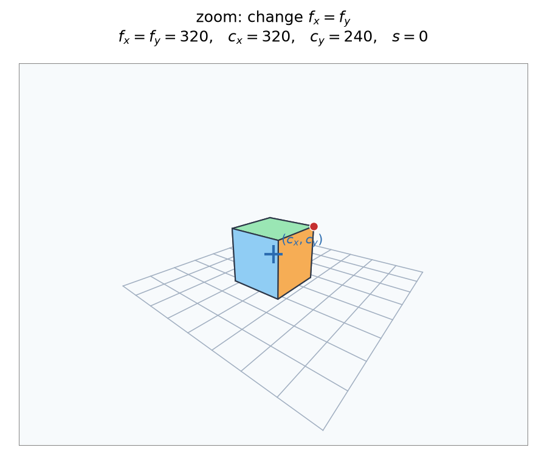

## Extrinsics in Action

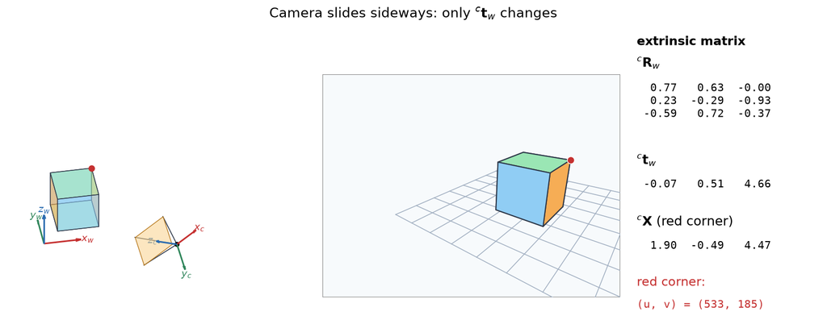

- $\mathbf{K}$ is fixed: every change in the image comes from the **extrinsic matrix** $\big[\,{}^{c}\mathbf{R}_{w} \mid {}^{c}\mathbf{t}_{w}\,\big]$, shown on the right.

## Projecting Points by Hand

```python
K = np.array([[500.0, 0.0, 320.0], [0.0, 500.0, 240.0], [0.0, 0.0, 1.0]]) # intrinsics
rvec = np.array([0.3, -0.4, 0.1])
R_c_w, _ = cv2.Rodrigues(rvec) # extrinsics rotation
t_c_w = np.array([[-0.4], [-0.3], [3.0]]) # extrinsics translation
P = K @ np.hstack([R_c_w, t_c_w]) # camera matrix

X_w = np.array([[x, y, z] for x in (0, 1) for y in (0, 1) for z in (0, 1)], dtype=float) # cube corners
X_w_h = np.hstack([X_w, np.ones((len(X_w), 1))]) # homogeneous coordinates
x = (P @ X_w_h.T).T # projection (lambda * u, lambda * v, lambda)
uv = x[:, :2] / x[:, 2:] # pixel coordinates (u, v)
```

- `rvec`: the rotation as a 3-vector (axis $\times$ angle); `cv2.Rodrigues` turns it into ${}^{c}\mathbf{R}_{w}$.
- `P` $= \mathbf{K}\,[\,{}^{c}\mathbf{R}_{w} \mid {}^{c}\mathbf{t}_{w}\,]$.
- `X_w_h` holds the corners as homogeneous rows.
- Each row of `x` is $\lambda\,(u, v, 1)$ with $\lambda = Z_c$; dividing by it gives `uv`.

[figure not shown]

## Projecting Points with OpenCV

```python
# Same rvec, t_c_w, K, and X_w as on the previous slide; None means no lens distortion.
uv_cv, _ = cv2.projectPoints(X_w, rvec, t_c_w, K, None)
uv_cv = uv_cv.reshape(-1, 2)
```

- `projectPoints` takes the rotation as `rvec` and applies $\mathbf{K}\,[\,{}^{c}\mathbf{R}_{w} \mid {}^{c}\mathbf{t}_{w}\,]$ internally.
- It returns an $(N, 1, 2)$ array; `reshape(-1, 2)` gives $N \times 2$ pixel coordinates.
- The last argument is the **lens distortion** model: `None` here.
  - We will cover it in the camera calibration lecture.

[figure not shown]

## Key Takeaways

- A pinhole forms an image by letting one ray from each scene point reach the sensor. A lens gathers more light; when in focus, its central rays follow the same geometry as the pinhole model.
- Perspective projection divides by depth: $x = fX/Z$, $y = fY/Z$. Distant objects appear smaller, and a single image point does not determine depth.
- Homogeneous coordinates represent points up to a nonzero scale and let us compose transformations through matrix multiplication. The rightmost transformation acts first; order matters.
- Affine transformations preserve parallelism and ratios along a line. Projective transformations preserve straight lines, but generally change parallelism and ratios.
- Extrinsics transform world coordinates into camera coordinates. Intrinsics determine how viewing directions map to pixels:

$$\underbrace{\lambda}_{\text{depth } Z_c}\,
\underbrace{\mathbf{x}}_{\substack{\text{pixel}\\ (u,\,v,\,1)}}
=
\overbrace{
\underbrace{\mathbf{K}}_{\substack{\text{intrinsics}\\ 3\times3}}\;
\underbrace{\big[\,{}^{c}\mathbf{R}_{w} \mid {}^{c}\mathbf{t}_{w}\,\big]}_{\substack{\text{extrinsics}\\ 3\times4}}
}^{\mathbf{P}:\ \text{camera matrix},\ 3\times4}\;
\underbrace{{}^{w}\mathbf{X}}_{\substack{\text{world point}\\ (X,\,Y,\,Z,\,1)}}$$

Divide by the last coordinate to recover the pixel coordinates $(u,v)$.